# Care Program Savings Methodology

Jon Wayland

Director of Data Science at Florida Blue

This document is meant for Florida Blue and affiliate use only. Please do not distribute. ©2021

[figure not shown]

# Overview

Like many ROI evaluations in healthcare, the methodology that Florida Blue uses to assess savings associated with Commercial Care programs utilizes a treatment-control approach. Unlike the majority of program evaluations, Florida Blue leverages a non-propensity matching metric in order to define “like members”. One of the downfalls with Propensity Matching is that it is subject to the ability to create a good logistic regression fit. For example, most propensity matching analyses incorporate covariates that violate assumptions (e.g. multi-collinearity) and result in a poor fit. If there is a poor fit, the quality of matches will typically suffer as a result. However, due to advances in computational power in recent years, the approach used takes advantage of building a distance matrix that represents similarity between every control member and every treatment member based on covariates with *mixed* data types. The distance metric used is called the [Gower Coefficient](https://www.jstor.org/stable/2528823?seq=1), and uses both continuous and categorical covariates. Gower Distance is traditionally used for clustering applications, although due to the inherit properties that allow for mixed data handling, the application of record matching proves appropriate.

What’s more, this application is shown to produce higher-quality matches than propensity scores. This comparison can be found in the **Examples** section (i.e. under the Full Example) while the matching methodology is described in more detail under the **Matching Methodology** section.

### Other Key Definitions

- Care Program - Initiative set out to improve member health
- Treatment Group - Members denoted as “engaged” per the Care Program of interest
- Control Group - Members identified for Care Program of interest but not “engaged”
- Engagement - Meaningful interaction as defined by the program
- Matching Quality - Mean absolute difference between matched pairs of covariates
- Repeated Random Sampling - Randomized samples of a specified size
- Savings Range - 25th-75th percentiles of the savings distribution
- Point Estimate - Median (50th percentile) of the savings distribution

# Data Pre-Processing

Skewness is a fairly common issue that healthcare data suffers from. More specifically, healthcare expenditures generally follow a right-skewed distribution where the top spenders represent the majority of costs.

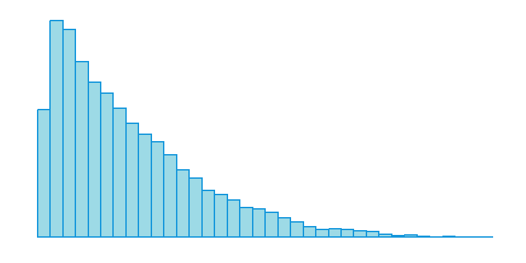

This skew can become very problematic when estimating savings. A common solution is to cap costs at a certain dollar threshold; however, it presents an inherit bias in the savings model. Capping introduces the issue of bucketing the *extreme* high-spenders in the same category as high-spenders. For example, a member with many inpatient admissions including one dedicated to a heart transplant incurring upwards of $1M would be reflecting the same amount of costs as a member on a single expensive maintenance drug at $115k.

In an effort to reduce this bias, the approach taken is to remove outliers using **Tukey’s Method for Outlier Detection** *prior* to matching and analysis, for both pre-engagement and post-engagement costs. There should be agreement on the outlier removal approach before implementation as the general method may not apply to specific programs.

The formula used is the following:

$$Q_3 + 1.5*(Q_3 - Q_1) \text{ where } Q_1 \text{ represents the first
quartile and } Q_3 \text{ represents the third quartile.}$$

In other words, cost observations that exceed 1.5 times the inner-quartile range *more* than the third quartile are removed.

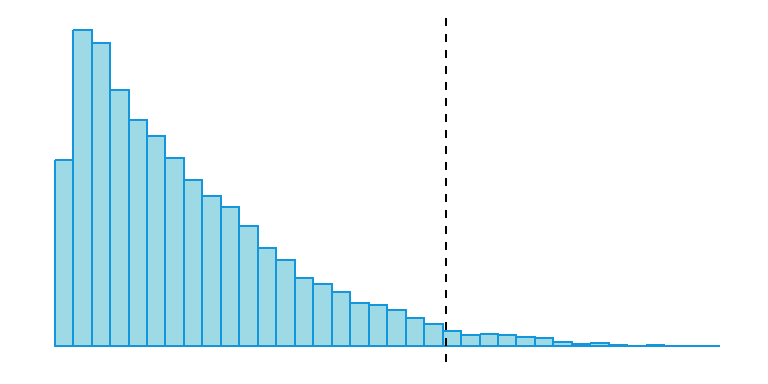

# Matching Methodology

As briefly described in the **Overview** section, the matching methodology leverages a distance metric called Gower Distance. This metric is defined as the partial dissimilarity between observation `i` and observation `j` as the following:

$$d_{ij} = \frac{1}{n} \sum_{p = 1}^{n}\frac{|x_{if} - x_{jf}|}{R_f}
\text{ where } R_f\text{ is the maximal range observed.}$$

In other words, the distance between member `i` and member `j` would be the mean dissimilarity across all variables considered. For any continuous variable, the dissimilarity translates to a value between `0` and `1` and represents the proportional difference that observation `i` is to observation `j` in comparison to the maximum possible difference (observed). As will be seen in our discussion of covariates used for matching, binary variables are a special case that translate to `0` if observation `i` is the same as observation `j`, and `1` otherwise.

# Discussion of Covariates

The covariates that may be used for matching consist of the following:

- Pre-Engaged Costs
- Percentage of Pre-Engaged Cost Relating to Retail Pharmacy
- Risk Score (as of the time of engagement)
- Count of Chronic and Potentially Disabling Conditions - [Chronic Condition Warehouse](https://www2.ccwdata.org/web/guest/condition-categories)
- Member Age
- Member Gender
- Area Deprivation Index (ADI) - [Neighborhood Atlas](https://www.neighborhoodatlas.medicine.wisc.edu)

The above collection of covariates used for matching include a clinical picture of a member (age, gender, condition count), the risk of a member, the expense of a member (pre-engaged costs), the category of expense (pharmacy percent), and the geographic deprivation the member faces (ADI). This collection is subject to change depending on the nuances of the program, but can serve as a good starting point on what to evaluate.

# Savings Definition

For a single match, savings are calculated as the difference of differences in “Control” pre/post engagement and “Treatment” pre/post engagement. More specifically, this is defined as the following:

$$\text{(Control Costs Post-Engagement - Control Costs Pre-Engagement) -
(Treatment Costs Post-Engagement - Treatment Costs Pre-Engagement)}$$

*Note:* Costs are reflective of total medical and pharmacy allowed amounts

The timeframe for pre-engaged costs is defined as 12 months prior to time of engagement, while the timeframe for post-engaged costs varies as a function of the program (generally 6-18 months post-engagement). The population savings (and range) is then a reflection of the distribution of matched pairs.

# Savings Range

It’s important to note that all savings estimates derived for program evaluation are just that: *estimates*. Any estimated value is only improved upon by including a range of what that value could have taken on. That said, the derived range is used for additional context while the point estimate is used for the final savings estimate.

In an effort to produce a range of savings as opposed to simply a point estimate, repeated random sampling (RRS) on the matched population is used to define a savings distribution. The RRS consists of 10k samples of 90% of the matched population. The 25th percentile of this distribution is used as the lower-end of the savings range while the 75th percentile is used as the upper-end of the savings range.

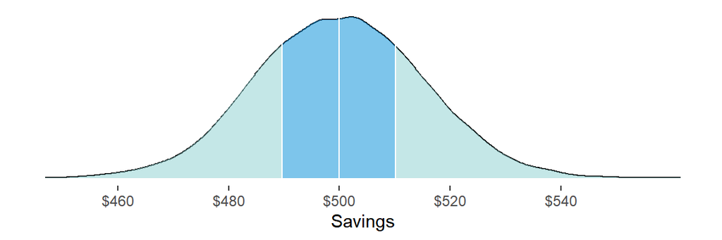

The produced range has the added benefit of outlier-sensitivity control. The previous removal of outliers accounts for individual observations, while the range of savings accounts for outliers existing in paired matches. For example, derived savings may be significantly different from the broader savings distribution post-matching, and thus this additional step allows for the removal of some of that noise.

# Examples

This section showcases two sets of examples. The first example - **Brief Example** - contains the actual calculation in order to find the best match and approximate a single matched pair of savings. The second example - **Full Example** - expands on the first by applying the methodology to a larger dataset and estimates the range and point estimate of the savings distribution across all matched pairs.

## Brief Example

For purposes of example, suppose we have four members with the following attributes where we are trying to match the `Treatment` member to the most appropriate `Control` member:

| Group | MemberID | Pre-Engaged Costs | Pharmacy Cost % | Risk | Condition Count | Age | Gender | ADI | Post-Engaged Costs |
| --- | --- | --- | --- | --- | --- | --- | --- | --- | --- |
| Treatment | A1 | $5,367 | 55% | 2.5 | 6 | 47 | M | 5.6 | $1,612 |
| Control | B2 | $2,344 | 45% | 3.1 | 7 | 53 | M | 6.8 | $2,125 |
| Control | C3 | $3,489 | 15% | 2.4 | 6 | 23 | F | 5.2 | $4,456 |
| Control | D4 | $6,004 | 59% | 2.6 | 6 | 49 | M | 5.4 | $1,924 |

Using the 7 matching variables, we can calculate the distance between Member A1 and Member B2 as follows:

- Member B2 Gower Coefficients
  - Pre-Engaged Costs:
    $$\frac{| \$5,367 -
    \$2,344 |} {\$6,004-\$2,344} = 0.8259563$$
  - Pharmacy Cost Percentage:
    $$\frac{| 55\%
    - 45\% |} {59\%-15\%} = 0.2272727$$
  - Risk
    $$\frac{| 2.5 - 3.1|} {3.1 - 2.4} =
    0.8571429$$
  - Condition Count
    $$\frac{| 6 - 7|} {7 - 6}
    = 1.0$$
  - Age
    $$\frac{| 47 - 53|} {53 - 23} =
    0.2$$
  - Gender
    $$\frac{|M - M|}{M-F} =
    \frac{0}{1} = 0.0$$
  - ADI
    $$\frac{|5.6 - 6.8|} {6.8 - 5.2} =
    0.75$$

Once the coefficients for each covariate are determined, we can take the average to derive the total distance between Member A1 and Member B2:
$$\frac{0.8259563 + 0.2272727 + 0.8571429
+ 1.0 + 0.2 + 0.0 + 0.75}{7} = 0.5514817$$

Repeating these steps for Member C3 and Member D4, we derive the following distances:

- Member C3 = 0.5164375
- Member D4 = 0.0856395

## Full Example

For purposes of a full example, we have generated a dataset using the [R programming language](https://www.r-project.org/) that reflects real-world healthcare data. The full code for data creation can be found in the **Appendix**.

Here we can see 5 random rows of the dataset:

|  | Group | MemberID | PreEngagedCosts | PharmacyCostPercentage | Risk |
| --- | --- | --- | --- | --- | --- |
| 196 | Control | Z477180743 | 24916.02 | 0.26 | 10 |
| 197 | Treatment | S461548877 | 4746.73 | 0.50 | 3 |
| 198 | Control | J505134026 | 6418.89 | 0.30 | 2 |
| 199 | Control | S169208096 | 5470.97 | 0.47 | 2 |
| 200 | Treatment | F176491577 | 4158.43 | 0.64 | 4 |

|  | ConditionCount | Age | Gender | ADI | PostEngagedCosts |
| --- | --- | --- | --- | --- | --- |
| 196 | 1 | 64.4 | M | 7.58 | 24959.283 |
| 197 | 1 | 64.7 | M | 2.67 | 4094.900 |
| 198 | 0 | 64.5 | M | 4.25 | 5943.633 |
| 199 | 1 | 61.7 | M | 4.73 | 5119.923 |
| 200 | 0 | 62.8 | F | 7.35 | 3808.658 |

This sample dataset contains 183 “Treatment” members and 817 “Control” members. In other words, the data simulates a program having a 18% engagement rate.

### Goal

As discussed previously, the goal is to match members from the “Treatment” group to the “Control” group. For purposes of comparison, we will first do this using Propensity score matching, and then using Gower Distance. Prior to performing any matches, however, we will remove outlying cost observations from the data (both pre and post).

```r
newdat <- mydat
newdat$Treatment <- ifelse(newdat$Group == 'Treatment',1,0)
```

### Data Pre-Processing

Using Tukey’s method, we identify the upper thresholds for both the pre-engaged costs as well as the post-engaged costs:

```r
tukeyHigh <- function(v){as.numeric(1.5*(quantile(v,0.75) - quantile(v,0.25)) + quantile(v,0.75))}
pre_threshold <- tukeyHigh(newdat$PreEngagedCosts)
post_threshold <- tukeyHigh(newdat$PostEngagedCosts)
```

The `pre_threshold` object is $58,584.47, while the `post_threshold` object is $59,570.49. Depending on the program, the cost distributions are subject to change, and thus using a strict threshold for capping could yield results that do not correspond to the distribution at hand. Additionally, the pre-engaged and post-engaged cost distributions generally differ for a variety of reasons, and thus the threshold is calculated separately for each. As a final point, the threshold is calculated *once* for both the “Treatment” and “Control” groups as the goal is to treat both of these groups the same.

Removing observations that exceed these thresholds results in dropping 92 members. 14 members are dropped out of the “Treatment” group and 78 members are dropped out of the “Control” group.

### Propensity Scores

```r
fit <- glm(Treatment ~ PreEngagedCosts + PharmacyCostPercentage + Risk + ConditionCount + Age + Gender + ADI + PostEngagedCosts,
           data = newdat,
           family = "binomial")
newdat$p_score <- predict(fit, data = newdat, type = "response")
```

If we use these scores to match “Treatment” members to their closest counterpart, we can accomplish a match using the nearest propensity score to *all* of these members. It’s important to note that for purposes of illustration, many “Treatment” members can be matched to a single “Control” member.

The average difference between the “Treatment” group’s propensity scores and the “Control” group’s propensity scores is 0.0004734615. In other words, the two groups are incredibly similar when it comes to the covariates used for deriving propensity scores. Additionally, the average absolute difference between each of the continuous covariates and the proportion difference by gender by matched pair is as follows:

| PreCost_Diff | PharmacyPercent_Diff | Risk_Diff | ConditionCount_Diff | Age_Diff | Gender_Diff | ADI_Diff |
| --- | --- | --- | --- | --- | --- | --- |
| 6872.156 | 0.3253846 | 0.7159763 | 0.887574 | 2.328994 | 0.4733728 | 3.338402 |

Keep these in mind as we will come back to them for comparison later.

### Gower Distance

Similar to the **Brief Example**, we can compute the Gower Distance between each “Treatment” member and each “Control” member. This time, however, an in-memory distance matrix is utilized to calculate these distances.

Like the **Propensity Scores** section, we can summarize the covariates of all of the matches by looking at the absolute difference between each of the continuous covariates by matched pairs. Again, Gender shows the proportion that are different.

| PreCost_Diff | PharmacyPercent_Diff | Risk_Diff | ConditionCount_Diff | Age_Diff | Gender_Diff | ADI_Diff |
| --- | --- | --- | --- | --- | --- | --- |
| 3119.261 | 0.0636686 | 0.408284 | 0.4733728 | 1.294675 | 0 | 0.5789941 |

**Note:** A good resource for calculating Gower distance is the [`StatMatch`](https://cran.r-project.org/web/packages/StatMatch/StatMatch.pdf) package (see the `gower.dist` function).

### Comparing Propensity Scores to Gower Distance

Let’s compare these next to one another to see the difference between the mean absolute differences in covariates by matched pair:

| Covariate | Propensity | Gower |
| --- | --- | --- |
| PreCost_Diff | 6872.1563905 | 3119.2605325 |
| PharmacyPercent_Diff | 0.3253846 | 0.0636686 |
| Risk_Diff | 0.7159763 | 0.4082840 |
| ConditionCount_Diff | 0.8875740 | 0.4733728 |
| Age_Diff | 2.3289941 | 1.2946746 |
| Gender_Diff | 0.4733728 | 0.0000000 |
| ADI_Diff | 3.3384024 | 0.5789941 |

It’s pretty clear that all of the absolute mean differences between matched pairs is smaller for the Gower matches as opposed to the Propensity matches. More specifically:

- Pre-Engaged Costs is roughly **2.2x** looser for Propensity matching than for Gower matching
- Nearly half of matched members are not the same gender for Propensity matches while all matched members are the same gender for Gower matching

Taking a closer look at a specific example as opposed to simply measuring population statistics is always a good exercise. Though this can be repeated for a large handful of members, we are choosing to assess “Treatment” member `I265124471` as it represents a good example of the comparative differences in the Propensity Matching as opposed to Gower Matching :

```r
colnames(match_example) <- c('Treatment Member', 'Propensity Matched Member', 'Gower Matched Member')

match_example %>%
  knitr::kable()
```

|  | Treatment Member | Propensity Matched Member | Gower Matched Member |
| --- | --- | --- | --- |
| MemberID | I265124471 | C309590856 | F692862551 |
| PreEngagedCosts | 1155.13 | 3658.41 | 985.85 |
| PharmacyCostPercentage | 0.67 | 0.5 | 0.66 |
| Risk | 1 | 2 | 1 |
| ConditionCount | 0 | 1 | 0 |
| Age | 59 | 62.8 | 61.6 |
| Gender | M | F | M |
| ADI | 5.89 | 0.95 | 5.87 |
| PropensityScore | 0.3064571 | 0.3072456 | 0.284464 |

Here we can see that the Propensity Scores for the “Treatment” member and their “Control” member counterpart are virtually equal when using Propensity Matching. Traditional research suggests that these two individuals are “common” in regard to the covariates used in the logistic regression. If we compare those values, however, we can see some relatively large differences:

- Pre-engaged costs are **3.2x higher** for the “Control” member than for the “Treatment” member
- Pharmacy represents two thirds of the pre-engaged costs for the “Treatment” member but only half for the “Control” member
- The risk score is **2x higher** for the “Control” member than for the “Treatment” member
- The condition count is 0 for the “Treatment” member and 1 for the “Control” member
- The gender of the “Treatment” member is male whereas the gender of the “Control” member is female
- The area deprivation (scale of 0-10) is **6.2x higher** for the “Treatment” member than for the “Control” member

If we are to compare this same “Treatment” member to their “Control” member counterpart when using Gower Matching, we can see that these differences are vastly less consequential.

Although further refinement can take place for “tightening” these matches (this would apply to **either** method), the out-of-the-box quality of matching has an obvious front-runner. As the goal for matching is to create the best “Apples to Apples” comparison with the data available, our goal is to **minimize** the above differences. For that reason, Gower Distance becomes the preferred method.

### Matching Quality Assessment

We recommended “tightening” the distance value for higher quality matches; However, this is generally at the discretion of the parties involved as it results in additional “Treatment” members being removed from the savings population.

One method is to allow a specified distance per covariate. For example, we may feel comfortable with a distance of 0.01 per covariate on average. Thus, an accepted distance threshold would be $p * 0.01$ where `p` represents the number of covariates. Another more common choice would be to scale that in half (i.e. 0.005 per covariate) to allow for more conservative matches. Following the 0.01 per covariate example, the distance threshold would be `0.07`:

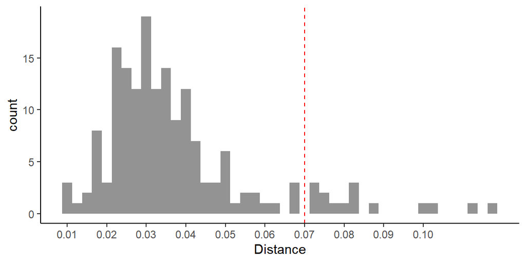

Performing this additional “tightening” results in losing 15 additional members. In general, the “tighter” the distance threshold, the higher quality and ultimately the more reliable the matched population is. Another common method for “tightening” is to remove matches that are qualified as outliers in the distance distribution using **Tukey’s Method**. Though it depends on the distribution, this approach is generally more conservative in favor of “tighter” matches.

Overall, it is advisable to use a smaller distance threshold if it *does not* result in a large proportion of members being removed. Whichever the case, this should be agreed upon prior to implementation.

### Repeated Random Sampling (RRS)

Now that we have a population of matched pairs, the next step is to derive a range of savings. To do this, we employ a repeated random sampling method to “flush” out some of the noise in our matches as well as develop a range that captures the middle 50% of samples.

```r
set.seed(9)
Savings <- replicate(10000,{
  tst <- matched_dat
  tst <- tst[sample(nrow(tst),round(0.9*nrow(tst)), replace = FALSE),]
  treat <- tst$T_PostEngagedCosts
  control <- tst$C_PostEngagedCosts
  mean(control - treat)
})
```

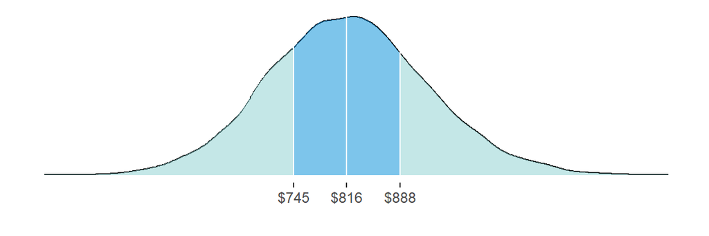

# Appendix

Code used for creation of the *Full Example* dataset:

```r
# Function for creating member IDs
memIDcreate <- function(n){
  mcr <- function(seed){set.seed(seed); rep(paste0(sample(LETTERS,1,replace = TRUE),
                    paste0(sample(seq(0,9,1),9,replace = TRUE), collapse = "")), 1)}
  sapply(seq(1,n,1),mcr)
}

# Setting total population size
total_pop <- 1000

# Correlated Variable Sets
mu <- rep(0,4)
Sigma <- matrix(.95, nrow=4, ncol=4) + diag(4)*.3
set.seed(2)
rawvars <- MASS::mvrnorm(n=total_pop, mu=mu, Sigma=Sigma)

# Pre-Engaged Costs
pre_cost <- rawvars[,1]
pre_cost<-pre_cost+abs(min(pre_cost)) # Converting to non-negative
set.seed(12)
pre_cost <- dgamma(pre_cost, shape = 1)
pre_cost <- round(pre_cost*500000/max(pre_cost),2)

# Pharmacy Cost Percentage
set.seed(4)
pharm_percent <- sample(seq(0,1,.01), total_pop, replace = TRUE)

# Condition Count
condition_cnt <- rawvars[,2]
condition_cnt <- condition_cnt+abs(min(condition_cnt)) # Converting to non-negative
set.seed(22)
condition_cnt <- dgamma(condition_cnt, shape = 1.1)
condition_cnt <- round(condition_cnt*25,0)

# Risk
Risk <- rawvars[,3]
Risk <- Risk+abs(min(Risk)) # Converting to non-negative
set.seed(12)
Risk <- dgamma(Risk, shape = 2.0)
Risk <- round(Risk*35,0)

# Ages
ages <- rawvars[,4]
ages <- ages+abs(min(ages)) # Converting to non-negative
set.seed(12)
ages <- dgamma(ages, shape = 4.05)
ages <- round((ages+1)*53,1)
set.seed(10)
ages[seq(10,900,100)] <- round(rnorm(length(seq(10,900,100)), 38, 10),1)

# Genders
set.seed(18)
genders <- sample(c('M', 'F'), total_pop, replace = TRUE)

# Post-Engaged Costs
set.seed(10)
post_cost <- pre_cost + rnorm(total_pop, 200, 500)

# ADI
set.seed(8)
adis <- round(runif(total_pop,0.1,9.9),2)

# Dataframe Creation
set.seed(5)
mydat <- data.frame(
  # Random selection of treatment vs. control groups
  Group = NA,
  # Member IDs
  MemberID = memIDcreate(total_pop),
  # Pre-Engaged Costs
  PreEngagedCosts = pre_cost,
  # Percentage of Pharmacy Costs
  PharmacyCostPercentage = pharm_percent,
  # Risk
  Risk = Risk,
  # Condition Count
  ConditionCount = condition_cnt,
  # Age
  Age = ages,
  # Gender
  Gender = genders,
  # ADI
  ADI = adis,
  # Post-Engaged Costs
  PostEngagedCosts = post_cost
)

# Generating random groups to create a "successful" program
for(i in 1:nrow(mydat)){
  set.seed(i)
  prob1 <- ifelse(post_cost[i] <= quantile(post_cost, 0.15), 0.95, 0.05)
  prob2 <- ifelse(post_cost[i] > quantile(post_cost, 0.35), 0.4, 0.6)
  set.seed(i+3)
  mydat$Group[i] <- sample(c('Treatment', 'Control'), total_pop, prob = c(prob1, prob2), replace = TRUE)
}
```